# End-to-End Economic & Social Indicators Analysis

How Economic, Health, and Education Factors Drive Human Development

Sana Ur Rehman Arain

2026-01-26

## 1. Executive Summary

This project investigates the **primary drivers of the Human Development Index (HDI)** using **4,200+ country–year observations (2000–2022)**. By integrating **World Bank economic indicators** with **UNDP human development data**, the analysis moves beyond correlation toward **predictive and explanatory modeling**.

### Key Findings

- **Non-Linearity Matters:** Random Forest outperformed Linear Regression by **54%** (RMSE **0.026 vs 0.056**), confirming that development follows complex, non-linear patterns.
- **Wealth vs. Well-Being:** While GDP per capita is the strongest single predictor, **Health Expenditure** and **Unemployment Rate** act as critical *bottlenecks* to development.
- **The Preston Curve Validated:** Economic growth delivers rapid HDI gains for low-income countries but **plateaus** among high-income economies.

## 2. Data Engineering & Quality

Two complementary datasets were combined using a rigorous **ETL (Extract–Transform–Load)** pipeline.

**Data Sources**

- **World Bank API:** Economic, labor, education, and health indicators
- **UNDP:** Human Development Index (HDI)

**Key Processing Steps**

- Harmonized country identifiers using **ISO3C codes**
- Constructed a balanced panel (2000–2022)
- Imputed missing values using **group-wise Down–Up filling**

### Final Dataset

- **4,290 observations**
- **15 development indicators**

```r
master_data <- read_csv("data/master_data_final.csv")

master_data %>%
  sample_n(5) %>%
  select(country, year, hdi, gdp_per_capita, life_expectancy_wb) %>%
  kable() %>%
  kable_styling(bootstrap_options = c("striped", "hover"), full_width = FALSE)
```

| country | year | hdi | gdp_per_capita | life_expectancy_wb |
| --- | --- | --- | --- | --- |
| Czechia | 2006 | 0.864 | 16107.3043 | 76.52439 |
| Niger | 2015 | 0.374 | 485.6626 | 58.85000 |
| Benin | 2007 | 0.469 | 926.7401 | 58.24900 |
| Marshall Islands | 2012 | 0.668 | 3420.9144 | 64.77600 |
| Mauritius | 2012 | 0.778 | 8702.8224 | 73.86341 |

## 3. Missing Data Diagnostics

Before imputation, we examined the structure of missingness to ensure data integrity.

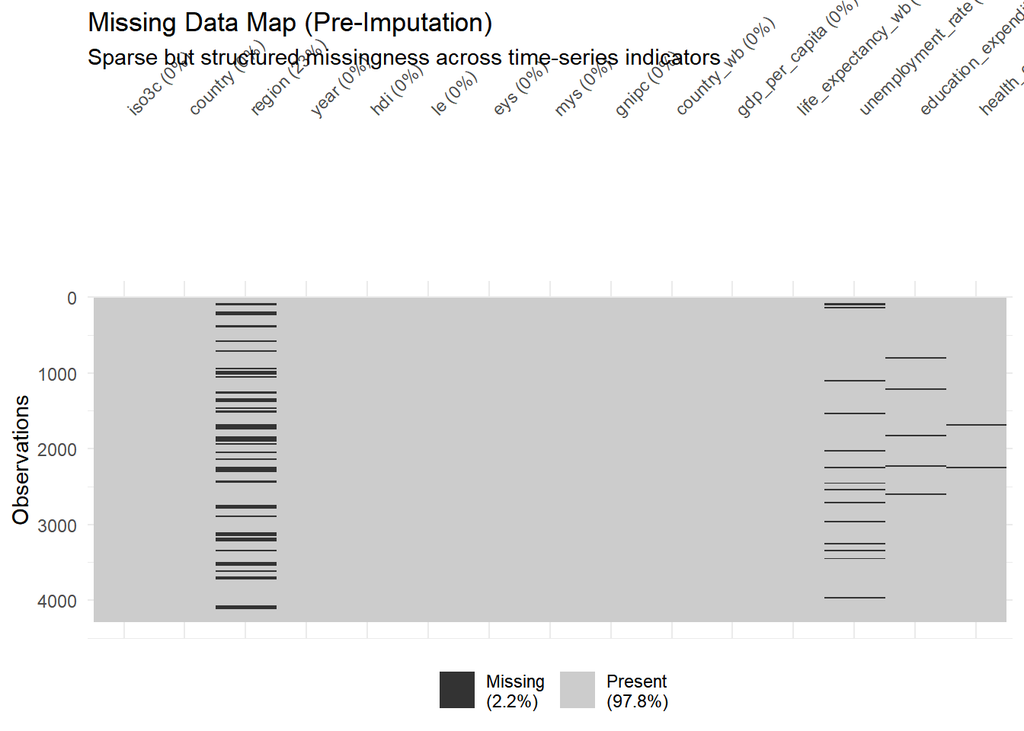

```r
vis_miss(master_data, warn_large_data = FALSE) +
  labs(
    title = "Missing Data Map (Pre-Imputation)",
    subtitle = "Sparse but structured missingness across time-series indicators"
  )
```

## 4. Exploratory Data Analysis (EDA)

### 4.1 Correlation Structure

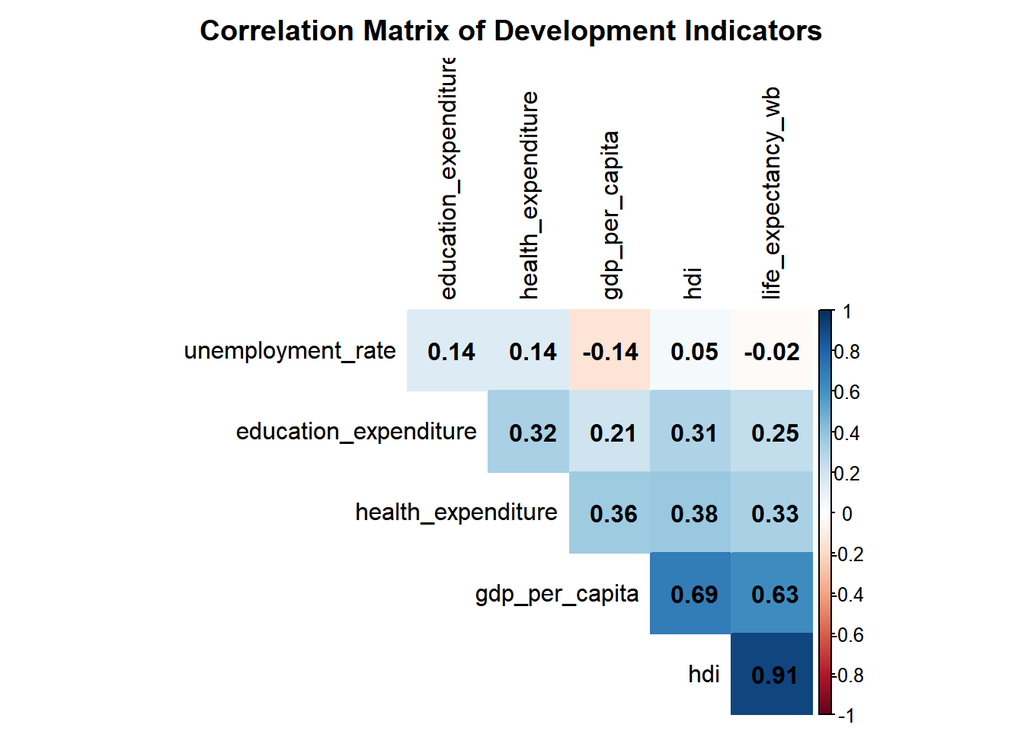

```r
numeric_data <- master_data %>%
  select(
    hdi, gdp_per_capita, life_expectancy_wb,
    unemployment_rate, education_expenditure,
    health_expenditure
  ) %>%
  drop_na()

cor_matrix <- cor(numeric_data)

corrplot(
  cor_matrix,
  method = "color",
  type = "upper",
  order = "hclust",
  addCoef.col = "black",
  tl.col = "black",
  diag = FALSE,
  title = "Correlation Matrix of Development Indicators",
  mar = c(0, 0, 2, 0)
)
```

### 4.2 The Preston Curve (Wealth vs. Health)

This figure visualizes **diminishing returns of income on health outcomes**.

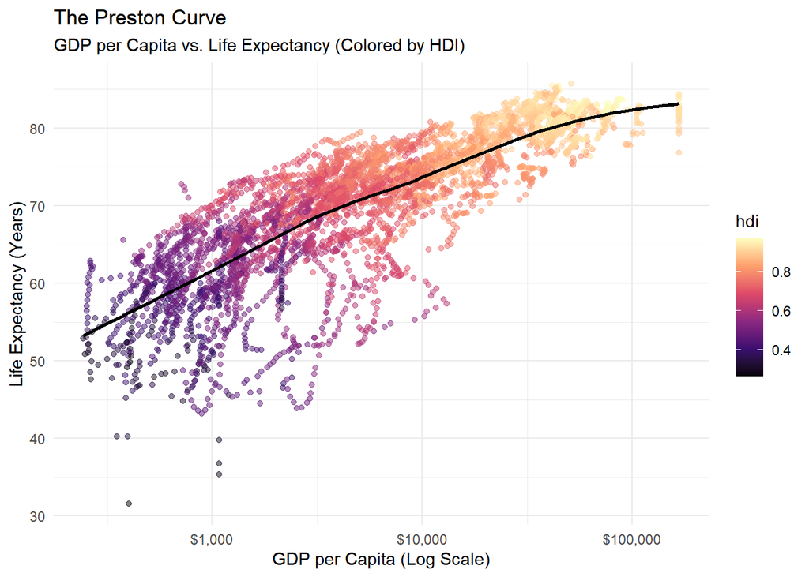

```r
ggplot(master_data, aes(
  x = gdp_per_capita,
  y = life_expectancy_wb,
  color = hdi
)) +
  geom_point(alpha = 0.5) +
  geom_smooth(method = "loess", color = "black", se = FALSE) +
  scale_x_log10(labels = scales::dollar) +
  scale_color_viridis_c(option = "magma") +
  theme_minimal() +
  labs(
    title = "The Preston Curve",
    subtitle = "GDP per Capita vs. Life Expectancy (Colored by HDI)",
    x = "GDP per Capita (Log Scale)",
    y = "Life Expectancy (Years)"
  )
```

### 4.3 Structural Clustering via PCA

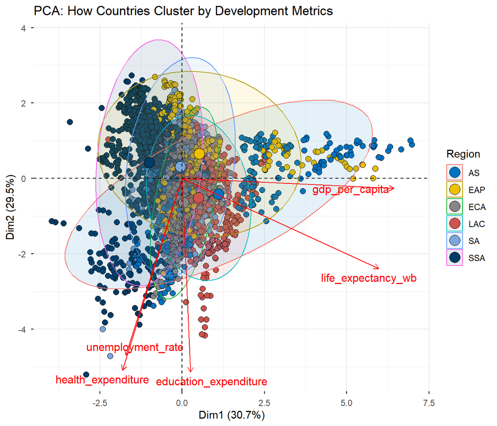

```r
pca_ready <- master_data %>%
  select(
    region, gdp_per_capita, life_expectancy_wb,
    unemployment_rate, education_expenditure,
    health_expenditure
  ) %>%
  drop_na()

pca_result <- prcomp(
  pca_ready %>% select(-region),
  center = TRUE,
  scale. = TRUE
)

fviz_pca_biplot(
  pca_result,
  geom.ind = "point",
  pointshape = 21,
  pointsize = 2.5,
  fill.ind = pca_ready$region,
  col.ind = "black",
  palette = "jco",
  addEllipses = TRUE,
  label = "var",
  col.var = "red",
  repel = TRUE,
  legend.title = "Region"
) +
  labs(title = "PCA: How Countries Cluster by Development Metrics")
```

## 5. Statistical Modeling & Machine Learning

We compare **Linear Regression** and **Random Forest** using an **80/20 train–test split**.

```r
set.seed(123)

model_data <- master_data %>%
  select(
    hdi, gdp_per_capita, life_expectancy_wb,
    unemployment_rate, education_expenditure,
    health_expenditure
  ) %>%
  drop_na()

data_split <- initial_split(model_data, prop = 0.80)
train_data <- training(data_split)
test_data  <- testing(data_split)
```

### 5.1 Feature Importance (Random Forest)

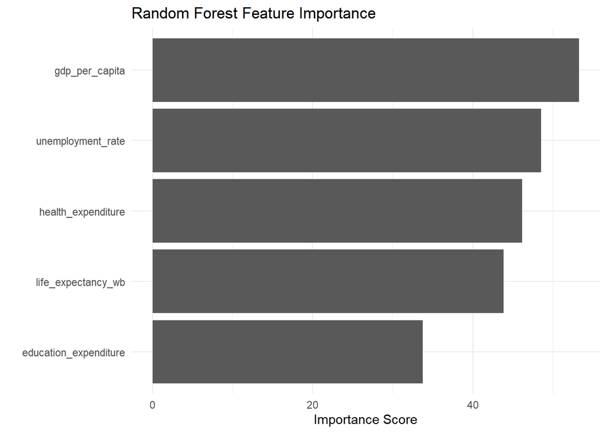

```r
rf_spec <- rand_forest(trees = 500, mode = "regression") %>%
  set_engine("randomForest", importance = TRUE)

rf_fit <- rf_spec %>% fit(hdi ~ ., data = train_data)

rf_fit %>%
  extract_fit_engine() %>%
  vip(geom = "col") +
  theme_minimal() +
  labs(
    title = "Random Forest Feature Importance",
    y = "Importance Score"
  )
```

### 5.2 Model Performance Comparison

```r
lm_spec <- linear_reg() %>% set_engine("lm")
lm_fit  <- lm_spec %>% fit(hdi ~ ., data = train_data)

results <- test_data %>%
  bind_cols(predict(lm_fit, test_data) %>% rename(LM = .pred)) %>%
  bind_cols(predict(rf_fit, test_data) %>% rename(RF = .pred))

bind_rows(
  results %>% metrics(hdi, LM) %>% mutate(Model = "Linear Regression"),
  results %>% metrics(hdi, RF) %>% mutate(Model = "Random Forest")
) %>%
  filter(.metric == "rmse") %>%
  select(Model, RMSE = .estimate) %>%
  arrange(RMSE) %>%
  kable() %>%
  kable_styling(full_width = FALSE, bootstrap_options = "striped")
```

| Model | RMSE |
| --- | --- |
| Random Forest | 0.0259180 |
| Linear Regression | 0.0562847 |

## 6. Conclusion

This analysis demonstrates that **economic growth is necessary but not sufficient** for human development. Once basic income thresholds are reached, **health investment and labor market conditions** become decisive.

From a policy perspective, the results strongly suggest that **social infrastructure—not income alone—drives long-run human well-being**.